# Proyecto_final_DS_Salaries

Juan Sebastian Oviedo Valencia

2023-06-06

# Fuente de datos

La base de datos utilizada contiene información de Salarios de puestos relacionados con cientificos de datos alrededor mundo, para, los datos son extraidos de una fuente de datas en kaggle [Data Science Salaries 2023] (https://www.kaggle.com/datasets/arnabchaki/data-science-salaries-2023).

El fin de usar esta base de datos es tener una vision del mercado laboral mundial y las oportunidades que nos esperan en el futuro, a la vez poer medio de este contrar un modelo lineal que nos permita generar un modelo que prediga los datos de salarios.

En los datos encontramos 11 Colunmnas:

- “work_year”, correspode al año donde se registro se obtuvo el registro.
- “experience_level”, corresponde al nivel de experiencia del trabajado.
- “employment_type”,corresponde al tipo de contrato que tiene el trabajado.
- “job_title”, es el nombre del cargo del trabajador.
- “salary”, es el salario neto al año.
- “salary_currency”, corresponde a la moneda en la que se debenga el salario.
- “salary_in_usd”, es la conversión del salario a dolares estadounidenses
- “employee_residence”, es el país donde se encuentra el trabajador.
- “remote_ratio”, corresponde a la tasa de trabajo que se realiza en remoto
- “company_location”: es el país donde se encuentra la compañia que ofrece el trbajo.
- “company_size”, es el tamaño de la compañia que ofrece el trabajo

## Siglas usadas

Algunas de lassiglas usadas en la fuente de datos son:

**Clasificación del Profesional**

- EN: Entry-level / Junior.
- MI: Mid-level / Intermediate.
- SE: Senior-level / Expert.
- EX: Executive-level / Director.

**Tipo de contrato**

- PT: Part-time
- FT: Full-time
- CT: Contract
- FL: Freelance

**Tamaño de la compañia**

- L: Grande
- M: Mediana
- S: Pequeña

```
##    work_year    experience_level employment_type
##  Min.   :2020   EN: 320          CT:  10
##  1st Qu.:2022   EX: 114          FL:  10
##  Median :2022   MI: 805          FT:3718
##  Mean   :2022   SE:2516          PT:  17
##  3rd Qu.:2023
##  Max.   :2023
##
##                      job_title        salary         salary_currency
##  Data Engineer            :1040   Min.   :    6000   USD    :3224
##  Data Scientist           : 840   1st Qu.:  100000   EUR    : 236
##  Data Analyst             : 612   Median :  138000   GBP    : 161
##  Machine Learning Engineer: 289   Mean   :  190696   INR    :  60
##  Analytics Engineer       : 103   3rd Qu.:  180000   CAD    :  25
##  Data Architect           : 101   Max.   :30400000   AUD    :   9
##  (Other)                  : 770                      (Other):  40
##  salary_in_usd    employee_residence  remote_ratio    company_location
##  Min.   :  5132   US     :3004       Min.   :  0.00   US     :3040
##  1st Qu.: 95000   GB     : 167       1st Qu.:  0.00   GB     : 172
##  Median :135000   CA     :  85       Median :  0.00   CA     :  87
##  Mean   :137570   ES     :  80       Mean   : 46.27   ES     :  77
##  3rd Qu.:175000   IN     :  71       3rd Qu.:100.00   IN     :  58
##  Max.   :450000   DE     :  48       Max.   :100.00   DE     :  56
##                   (Other): 300                        (Other): 265
##  company_size
##  L: 454
##  M:3153
##  S: 148
##
##
##
##
```

## **Resumen de los datos**

Observamos que que tenemos 11 columnas, 3755 registros.

Las columnas numericas son: años de experiencia, Salario

Las variables categoricas son: nivel de experiecia, Tipo de contrato, Titulo del cargo, moneda, Residencia del empleado, Localizacion de la empresa y Tamaño de la empresa.

## Análisis exploratorio

### Análisis de inicial de los datos

```
## [1] 2023 2022 2020 2021
```

Comenzando con la columana “work_year”, se identifica que no son numeros si no años los datos de la columna, es por esto que se decide convertirlo los valores a tipo factor

```
## [1] 100   0  50
```

En la columna remote_ratio se identifica que tambien se trata de solo 3 datos para referirse al trabajo remoto, es por ello que se decide cambiar estos datos numericos por factor dejandolo asi:

- remote => re = 100
- hybrid => hy = 50
- presential => pr = 0

Se decide eliminar la columna salary para trabajar con una moneda comun, sin embargo, se deja la columna salary_currency para verificar si existe alguna diferencia por el tipo de moneda en la que gana

```
##  work_year   experience_level employment_type                     job_title
##  2020:  76   EN: 320          CT:  10         Data Engineer            :1040
##  2021: 230   EX: 114          FL:  10         Data Scientist           : 840
##  2022:1664   MI: 805          FT:3718         Data Analyst             : 612
##  2023:1785   SE:2516          PT:  17         Machine Learning Engineer: 289
##                                               Analytics Engineer       : 103
##                                               Data Architect           : 101
##                                               (Other)                  : 770
##  salary_currency salary_in_usd    employee_residence remote_ratio
##  USD    :3224    Min.   :  5132   US     :3004       HY: 189
##  EUR    : 236    1st Qu.: 95000   GB     : 167       PR:1923
##  GBP    : 161    Median :135000   CA     :  85       RE:1643
##  INR    :  60    Mean   :137570   ES     :  80
##  CAD    :  25    3rd Qu.:175000   IN     :  71
##  AUD    :   9    Max.   :450000   DE     :  48
##  (Other):  40                     (Other): 300
##  company_location company_size
##  US     :3040     L: 454
##  GB     : 172     M:3153
##  CA     :  87     S: 148
##  ES     :  77
##  IN     :  58
##  DE     :  56
##  (Other): 265
```

# Verificamos si hay faltantes

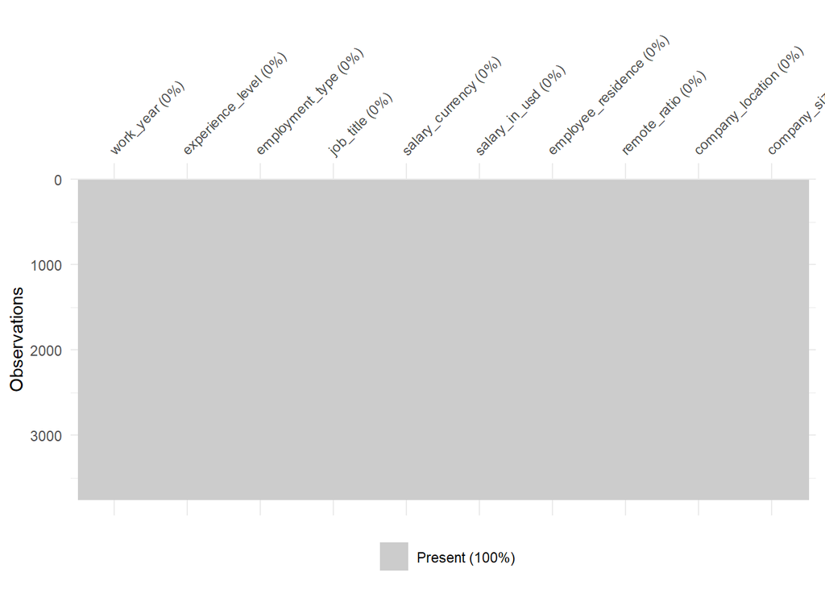

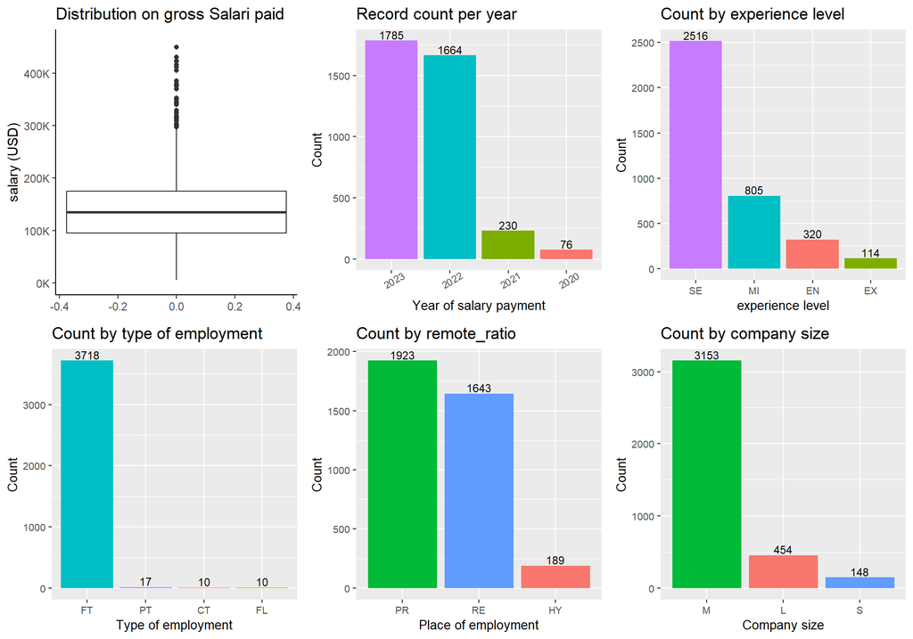

[interactive chart not shown]

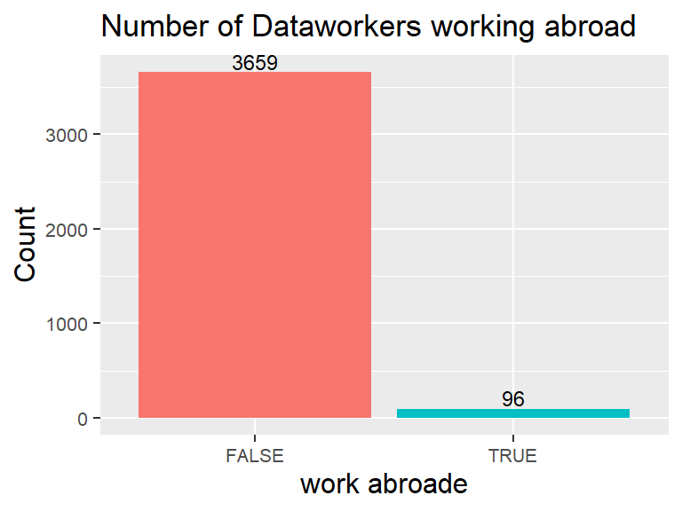

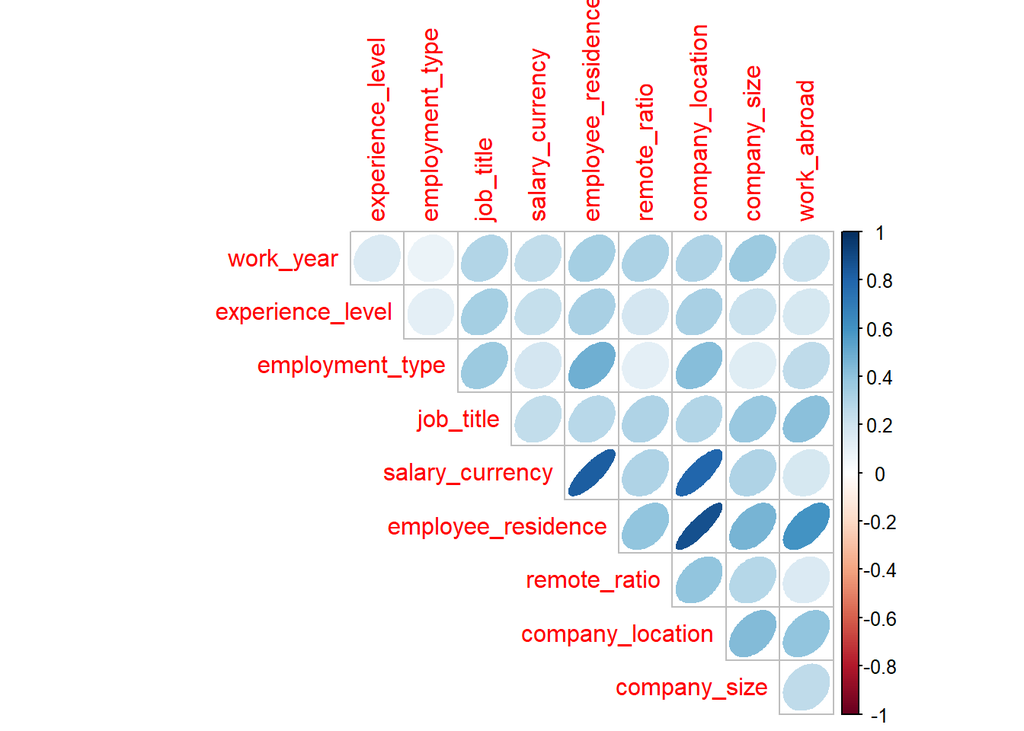

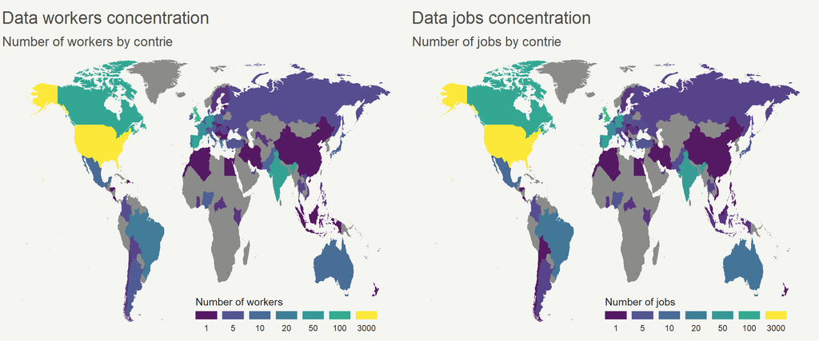

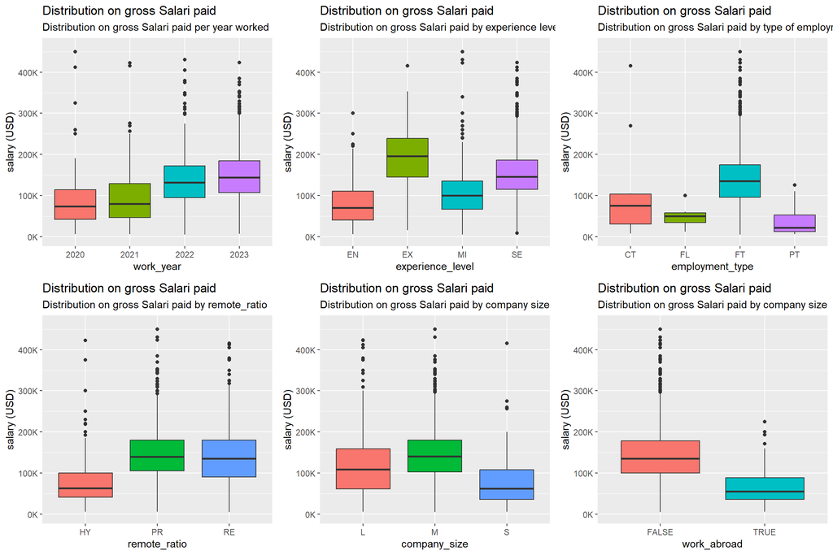

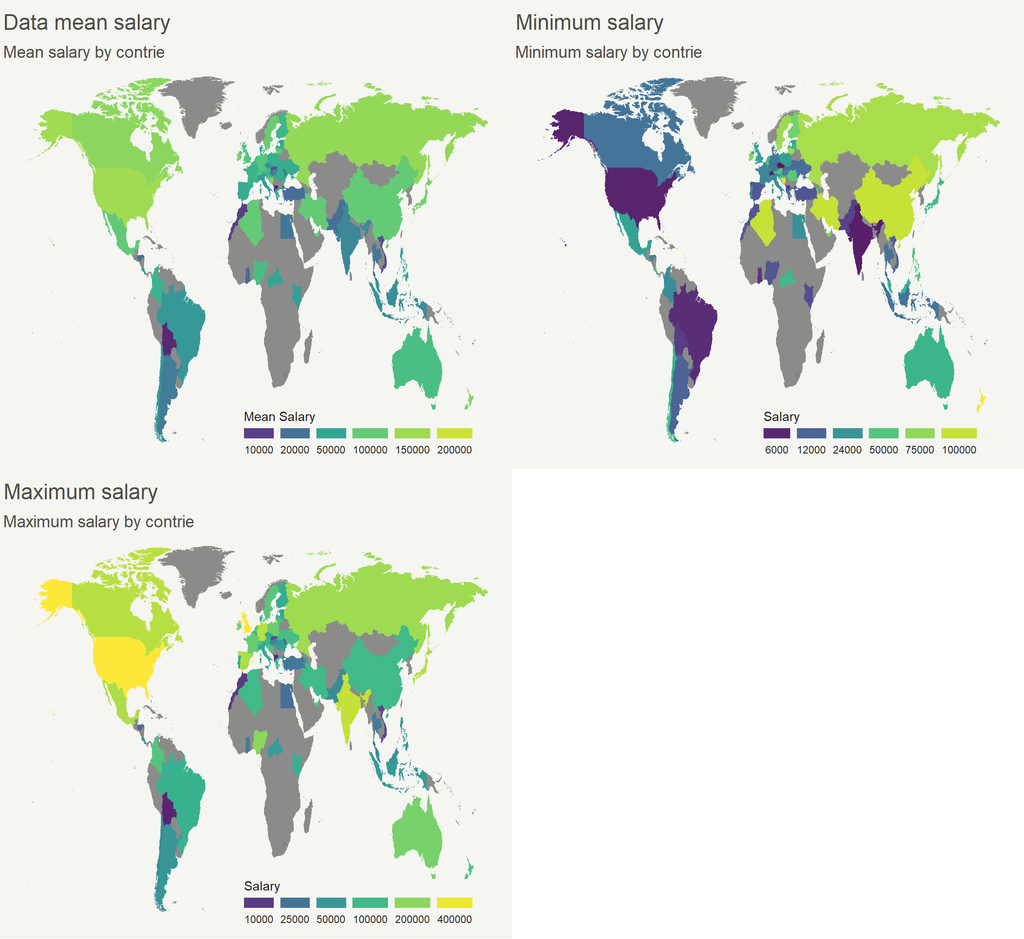

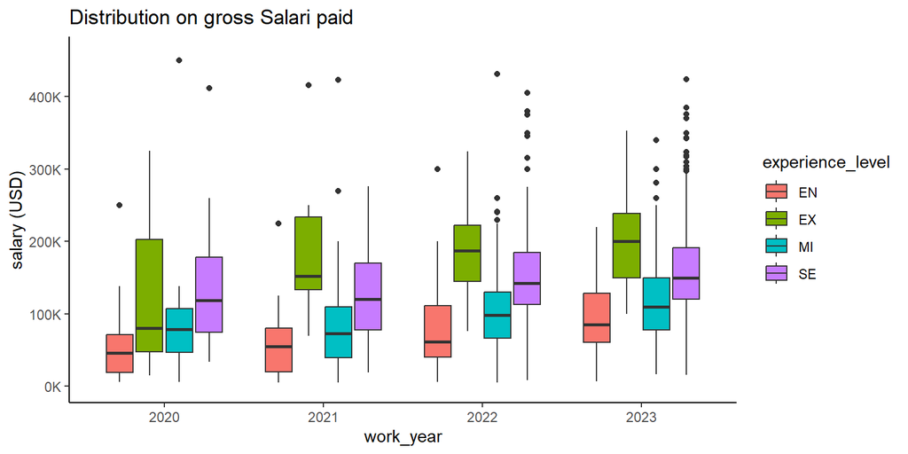

```
##
## Call:
## lm(formula = formula_sat, data = data)
##
## Residuals:
##     Min      1Q  Median      3Q     Max
## -129643  -28616   -4375   22815  378157
##
## Coefficients: (37 not defined because of singularities)
##                                                     Estimate Std. Error t value
## (Intercept)                                       -7.804e+06  2.779e+06  -2.808
## work_year                                          3.846e+03  1.375e+03   2.796
## experience_levelEX                                 8.525e+04  5.813e+03  14.665
## experience_levelMI                                 2.188e+04  3.516e+03   6.222
## experience_levelSE                                 4.448e+04  3.299e+03  13.485
## employment_typeFL                                 -2.371e+04  3.003e+04  -0.789
## employment_typeFT                                  2.037e+03  1.885e+04   0.108
## employment_typePT                                 -1.464e+04  2.448e+04  -0.598
## job_titleAI Developer                              9.116e+04  5.342e+04   1.706
## job_titleAI Programmer                            -3.614e+04  6.858e+04  -0.527
## job_titleAI Scientist                              2.594e+04  5.161e+04   0.503
## job_titleAnalytics Engineer                        6.648e+03  5.014e+04   0.133
## job_titleApplied Data Scientist                    4.112e+04  5.299e+04   0.776
## job_titleApplied Machine Learning Engineer         1.781e+04  6.112e+04   0.291
## job_titleApplied Machine Learning Scientist        3.072e+04  5.251e+04   0.585
## job_titleApplied Scientist                         3.890e+04  5.043e+04   0.771
## job_titleAutonomous Vehicle Technician             1.713e+04  8.391e+04   0.204
## job_titleAzure Data Engineer                      -2.638e+04  7.028e+04  -0.375
## job_titleBI Analyst                               -4.941e+03  5.250e+04  -0.094
## job_titleBI Data Analyst                          -1.036e+04  5.168e+04  -0.200
## job_titleBI Data Engineer                         -5.069e+04  6.845e+04  -0.741
## job_titleBI Developer                             -1.796e+04  5.161e+04  -0.348
## job_titleBig Data Architect                        2.692e+04  6.000e+04   0.449
## job_titleBig Data Engineer                         1.970e+04  5.292e+04   0.372
## job_titleBusiness Data Analyst                    -1.657e+04  5.146e+04  -0.322
## job_titleBusiness Intelligence Engineer            1.868e+04  5.509e+04   0.339
## job_titleCloud Data Architect                      9.991e+04  6.828e+04   1.463
## job_titleCloud Data Engineer                       5.804e+04  6.736e+04   0.862
## job_titleCloud Database Engineer                   6.593e+02  5.414e+04   0.012
## job_titleCompliance Data Analyst                  -8.086e+04  7.253e+04  -1.115
```

[output cut: 506 more lines]

```
## company_locationSK                                      NA
## company_locationTH                                      NA
## company_locationTR                                      NA
## company_locationUA                                      NA
## company_locationUS                                0.909582
## company_locationVN                                      NA
## company_sizeM                                     0.247347
## company_sizeS                                     0.000127 ***
## work_abroadTRUE                                   0.455041
## ---
## Signif. codes:  0 '***' 0.001 '**' 0.01 '*' 0.05 '.' 0.1 ' ' 1
##
## Residual standard error: 46520 on 3520 degrees of freedom
## Multiple R-squared:  0.4896, Adjusted R-squared:  0.4556
## F-statistic: 14.43 on 234 and 3520 DF,  p-value: < 2.2e-16
```

```
## Analysis of Variance Table
##
## Response: salary_in_usd
##                      Df     Sum Sq    Mean Sq  F value    Pr(>F)
## work_year             1 7.7789e+11 7.7789e+11 359.3941 < 2.2e-16 ***
## experience_level      3 2.5030e+12 8.3433e+11 385.4719 < 2.2e-16 ***
## employment_type       3 5.1946e+10 1.7315e+10   8.0000 2.594e-05 ***
## job_title            92 1.4057e+12 1.5279e+10   7.0593 < 2.2e-16 ***
## salary_currency      19 1.8617e+12 9.7983e+10  45.2694 < 2.2e-16 ***
## employee_residence   73 5.9059e+11 8.0903e+09   3.7378 < 2.2e-16 ***
## remote_ratio          2 3.5110e+08 1.7555e+08   0.0811 0.9220971
## company_location     38 8.3286e+10 2.1917e+09   1.0126 0.4484065
## company_size          2 3.1499e+10 1.5749e+10   7.2764 0.0007021 ***
## work_abroad           1 1.2082e+09 1.2082e+09   0.5582 0.4550410
## Residuals          3520 7.6188e+12 2.1644e+09
## ---
## Signif. codes:  0 '***' 0.001 '**' 0.01 '*' 0.05 '.' 0.1 ' ' 1
```

```
## [1] 91600.88
```

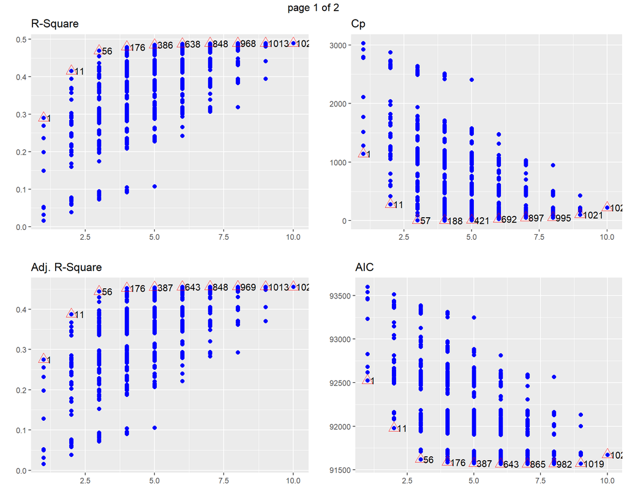

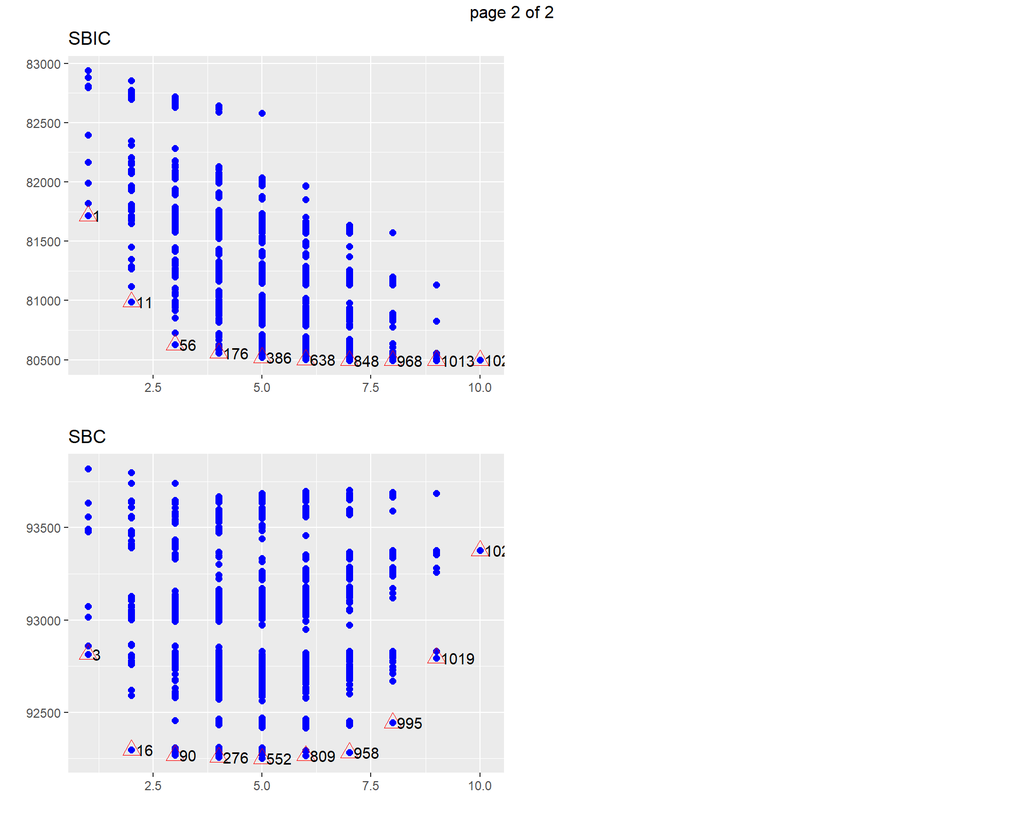

```
## [1] "experience_level job_title salary_currency employee_residence"
```

```
## [1] 91587.91
```

```
## [1] 0.479534
```

```
## [1] 0.4522486
```

```
## [1] "experience_level job_title salary_currency employee_residence company_size"
```

```
## [1] 91574.8
```

```
## [1] 0.4819001
```

```
## [1] 0.4544328
```

```
## [1] "experience_level job_title employee_residence"
```

```
## [1] 91621.73
```

```
## [1] 0.4694832
```

```
## [1] 0.4440089
```

```
## Start:  AIC=80942.65
## salary_in_usd ~ work_year + experience_level + employment_type +
##     job_title + salary_currency + employee_residence + remote_ratio +
##     company_location + company_size + work_abroad
##
##                      Df  Sum of Sq        RSS   AIC
## - company_location   38 8.3253e+10 7.7021e+12 80907
## - employee_residence 42 1.0781e+11 7.7266e+12 80911
## - remote_ratio        2 1.5790e+08 7.6190e+12 80939
## - employment_type     3 4.6526e+09 7.6235e+12 80939
## - work_abroad         1 1.2082e+09 7.6200e+12 80941
## <none>                             7.6188e+12 80943
## - work_year           1 1.6923e+10 7.6357e+12 80949
## - company_size        2 3.1857e+10 7.6507e+12 80954
## - salary_currency    13 1.2718e+11 7.7460e+12 80979
## - experience_level    3 7.0980e+11 8.3286e+12 81271
## - job_title          92 1.4175e+12 9.0364e+12 81399
##
## Step:  AIC=80907.46
## salary_in_usd ~ work_year + experience_level + employment_type +
##     job_title + salary_currency + employee_residence + remote_ratio +
##     company_size + work_abroad
##
##                      Df  Sum of Sq        RSS   AIC
## - remote_ratio        2 1.7859e+09 7.7039e+12 80904
## - employment_type     3 6.9049e+09 7.7090e+12 80905
## - work_abroad         1 2.6014e+09 7.7047e+12 80907
## <none>                             7.7021e+12 80907
## - work_year           1 1.6007e+10 7.7181e+12 80913
## - company_size        2 2.9476e+10 7.7315e+12 80918
## - salary_currency    15 1.4889e+11 7.8510e+12 80949
## - employee_residence 73 5.2044e+11 8.2225e+12 81007
## - experience_level    3 7.2462e+11 8.4267e+12 81239
## - job_title          92 1.4177e+12 9.1198e+12 81358
##
## Step:  AIC=80904.33
## salary_in_usd ~ work_year + experience_level + employment_type +
##     job_title + salary_currency + employee_residence + company_size +
##     work_abroad
##
```

[output cut: 22 more lines]

```
## - experience_level    3 7.3616e+11 8.4475e+12 81238
## - job_title          92 1.4197e+12 9.1310e+12 81353
##
## Step:  AIC=80901.57
## salary_in_usd ~ work_year + experience_level + job_title + salary_currency +
##     employee_residence + company_size
##
##                      Df  Sum of Sq        RSS   AIC
## <none>                             7.7146e+12 80902
## - work_year           1 1.8513e+10 7.7331e+12 80909
## - company_size        2 3.2718e+10 7.7473e+12 80913
## - salary_currency    15 1.4544e+11 7.8601e+12 80942
## - employee_residence 73 5.8356e+11 8.2982e+12 81029
## - experience_level    3 7.3464e+11 8.4493e+12 81237
## - job_title          92 1.4200e+12 9.1346e+12 81352
```

```
##
## Call:
## lm(formula = salary_in_usd ~ work_year + experience_level + job_title +
##     salary_currency + employee_residence + company_size, data = data)
##
## Residuals:
##     Min      1Q  Median      3Q     Max
## -130008  -29240   -4669   23098  378456
##
## Coefficients: (4 not defined because of singularities)
##                                                     Estimate Std. Error t value
## (Intercept)                                       -7924699.0  2696436.8  -2.939
## work_year                                             3900.3     1333.7   2.925
## experience_levelEX                                   84215.1     5724.7  14.711
## experience_levelMI                                   21594.5     3399.1   6.353
## experience_levelSE                                   44506.7     3192.6  13.940
## job_titleAI Developer                               147051.6    32094.0   4.582
## job_titleAI Programmer                               56391.5    43679.4   1.291
## job_titleAI Scientist                                75298.9    28541.6   2.638
## job_titleAnalytics Engineer                          58690.3    26569.3   2.209
## job_titleApplied Data Scientist                      79332.2    30733.2   2.581
## job_titleApplied Machine Learning Engineer           71308.1    42766.8   1.667
## job_titleApplied Machine Learning Scientist          83504.6    30258.8   2.760
## job_titleApplied Scientist                           90947.5    26902.8   3.381
## job_titleAutonomous Vehicle Technician               35026.6    48681.9   0.720
## job_titleAzure Data Engineer                         30463.9    55375.5   0.550
## job_titleBI Analyst                                  44071.8    30718.7   1.435
## job_titleBI Data Analyst                             43551.3    29075.8   1.498
## job_titleBI Data Engineer                             1550.7    53421.5   0.029
## job_titleBI Developer                                34313.8    29168.8   1.176
## job_titleBig Data Architect                          79154.6    42399.0   1.867
## job_titleBig Data Engineer                           68744.3    30648.7   2.243
## job_titleBusiness Data Analyst                       36427.3    29026.1   1.255
## job_titleBusiness Intelligence Engineer              71193.9    35021.8   2.033
## job_titleCloud Data Architect                       150638.5    53458.7   2.818
## job_titleCloud Data Engineer                        101891.7    44887.2   2.270
## job_titleCloud Database Engineer                     52762.9    33437.6   1.578
## job_titleCompliance Data Analyst                    -20268.8    58270.5  -0.348
## job_titleComputer Vision Engineer                    92908.8    28383.9   3.273
## job_titleComputer Vision Software Engineer           65734.7    34871.6   1.885
```

[output cut: 353 more lines]

```
## employee_residenceTH                              0.394565
## employee_residenceTN                              0.873055
## employee_residenceTR                              0.132533
## employee_residenceUA                              0.040545 *
## employee_residenceUS                              0.044507 *
## employee_residenceUZ                              0.867355
## employee_residenceVN                              0.211254
## company_sizeM                                     0.149860
## company_sizeS                                     0.000106 ***
## ---
## Signif. codes:  0 '***' 0.001 '**' 0.01 '*' 0.05 '.' 0.1 ' ' 1
##
## Residual standard error: 46530 on 3564 degrees of freedom
## Multiple R-squared:  0.4831, Adjusted R-squared:  0.4556
## F-statistic: 17.53 on 190 and 3564 DF,  p-value: < 2.2e-16
```

```
## Analysis of Variance Table
##
## Response: salary_in_usd
##                      Df     Sum Sq    Mean Sq  F value    Pr(>F)
## work_year             1 7.7789e+11 7.7789e+11 359.3677 < 2.2e-16 ***
## experience_level      3 2.5030e+12 8.3433e+11 385.4435 < 2.2e-16 ***
## job_title            92 1.4143e+12 1.5372e+10   7.1017 < 2.2e-16 ***
## salary_currency      19 1.8626e+12 9.8032e+10  45.2888 < 2.2e-16 ***
## employee_residence   73 6.2087e+11 8.5051e+09   3.9292 < 2.2e-16 ***
## company_size          2 3.2718e+10 1.6359e+10   7.5575 0.0005306 ***
## Residuals          3564 7.7146e+12 2.1646e+09
## ---
## Signif. codes:  0 '***' 0.001 '**' 0.01 '*' 0.05 '.' 0.1 ' ' 1
```

```
## [1] 91559.8
```

```
## Analysis of Variance Table
##
## Response: salary_in_usd
##                      Df     Sum Sq    Mean Sq  F value    Pr(>F)
## experience_level      3 2.9719e+12 9.9063e+11 456.6835 < 2.2e-16 ***
## job_title            92 1.4613e+12 1.5883e+10   7.3223 < 2.2e-16 ***
## salary_currency      19 2.0788e+12 1.0941e+11  50.4391 < 2.2e-16 ***
## employee_residence   73 6.4552e+11 8.8427e+09   4.0765 < 2.2e-16 ***
## company_size          2 3.5316e+10 1.7658e+10   8.1405  0.000297 ***
## Residuals          3565 7.7331e+12 2.1692e+09
## ---
## Signif. codes:  0 '***' 0.001 '**' 0.01 '*' 0.05 '.' 0.1 ' ' 1
```

```
## [1] 91566.8
```

```
## Analysis of Variance Table
##
## Model 1: salary_in_usd ~ 1
## Model 2: salary_in_usd ~ work_year + experience_level + employment_type +
##     job_title + salary_currency + employee_residence + remote_ratio +
##     company_location + company_size + work_abroad
## Model 3: salary_in_usd ~ experience_level + job_title + salary_currency +
##     employee_residence + company_size
## Model 4: salary_in_usd ~ work_year + experience_level + job_title + salary_currency +
##     employee_residence + company_size
##   Res.Df        RSS  Df   Sum of Sq       F    Pr(>F)
## 1   3754 1.4926e+13
## 2   3520 7.6188e+12 234  7.3071e+12 14.4273 < 2.2e-16 ***
## 3   3565 7.7331e+12 -45 -1.1432e+11  1.1737  0.199621
## 4   3564 7.7146e+12   1  1.8513e+10  8.5535  0.003471 **
## ---
## Signif. codes:  0 '***' 0.001 '**' 0.01 '*' 0.05 '.' 0.1 ' ' 1
```